# Risk Factor Analysis

## Outcome Variable

**Outcome Variable:** haz

## Predictor Variables

**Intervention Variable:** hdlvry

**Adjustment Set:**

- arm
- sex
- W_mage
- meducyrs
- feducyrs
- hhwealth_quart
- single
- W_nrooms
- brthmon
- W_parity
- impsan
- delta_W_mage
- delta_meducyrs
- delta_feducyrs
- delta_hhwealth_quart
- delta_single
- delta_W_nrooms
- delta_brthmon
- delta_W_parity
- delta_impsan

## Stratifying Variables

The analysis was stratified on these variable(s):

- agecat
- studyid
- country

## Data Summary

| agecat | studyid | country | hdlvry | n_cell | n |
| --- | --- | --- | --- | --- | --- |
| Birth | CMC-V-BCS-2002 | INDIA | 0 | 92 | 92 |
| Birth | CMC-V-BCS-2002 | INDIA | 1 | 0 | 92 |
| Birth | COHORTS | INDIA | 0 | 2938 | 4694 |
| Birth | COHORTS | INDIA | 1 | 1756 | 4694 |
| Birth | EE | PAKISTAN | 0 | 161 | 238 |
| Birth | EE | PAKISTAN | 1 | 77 | 238 |
| Birth | GMS-Nepal | NEPAL | 0 | 157 | 646 |
| Birth | GMS-Nepal | NEPAL | 1 | 489 | 646 |
| Birth | IRC | INDIA | 0 | 381 | 388 |
| Birth | IRC | INDIA | 1 | 7 | 388 |
| Birth | JiVitA-3 | BANGLADESH | 0 | 30 | 334 |
| Birth | JiVitA-3 | BANGLADESH | 1 | 304 | 334 |
| Birth | JiVitA-4 | BANGLADESH | 0 | 554 | 2808 |
| Birth | JiVitA-4 | BANGLADESH | 1 | 2254 | 2808 |
| Birth | NIH-Crypto | BANGLADESH | 0 | 567 | 732 |
| Birth | NIH-Crypto | BANGLADESH | 1 | 165 | 732 |
| Birth | PROVIDE | BANGLADESH | 0 | 391 | 539 |
| Birth | PROVIDE | BANGLADESH | 1 | 148 | 539 |
| Birth | SAS-CompFeed | INDIA | 0 | 124 | 1085 |
| Birth | SAS-CompFeed | INDIA | 1 | 961 | 1085 |
| 6 months | CMC-V-BCS-2002 | INDIA | 0 | 358 | 366 |
| 6 months | CMC-V-BCS-2002 | INDIA | 1 | 8 | 366 |
| 6 months | COHORTS | INDIA | 0 | 2900 | 4699 |
| 6 months | COHORTS | INDIA | 1 | 1799 | 4699 |
| 6 months | EE | PAKISTAN | 0 | 250 | 371 |
| 6 months | EE | PAKISTAN | 1 | 121 | 371 |
| 6 months | GMS-Nepal | NEPAL | 0 | 129 | 528 |
| 6 months | GMS-Nepal | NEPAL | 1 | 399 | 528 |
| 6 months | IRC | INDIA | 0 | 399 | 407 |
| 6 months | IRC | INDIA | 1 | 8 | 407 |
| 6 months | JiVitA-3 | BANGLADESH | 0 | 39 | 332 |
| 6 months | JiVitA-3 | BANGLADESH | 1 | 293 | 332 |
| 6 months | JiVitA-4 | BANGLADESH | 0 | 1081 | 4038 |
| 6 months | JiVitA-4 | BANGLADESH | 1 | 2957 | 4038 |
| 6 months | NIH-Crypto | BANGLADESH | 0 | 554 | 715 |
| 6 months | NIH-Crypto | BANGLADESH | 1 | 161 | 715 |
| 6 months | PROVIDE | BANGLADESH | 0 | 450 | 604 |
| 6 months | PROVIDE | BANGLADESH | 1 | 154 | 604 |
| 6 months | SAS-CompFeed | INDIA | 0 | 147 | 1091 |
| 6 months | SAS-CompFeed | INDIA | 1 | 944 | 1091 |
| 6 months | SAS-FoodSuppl | INDIA | 0 | 76 | 380 |
| 6 months | SAS-FoodSuppl | INDIA | 1 | 304 | 380 |
| 6 months | TanzaniaChild2 | TANZANIA, UNITED REPUBLIC OF | 0 | 1889 | 1921 |
| 6 months | TanzaniaChild2 | TANZANIA, UNITED REPUBLIC OF | 1 | 32 | 1921 |
| 24 months | CMC-V-BCS-2002 | INDIA | 0 | 360 | 368 |
| 24 months | CMC-V-BCS-2002 | INDIA | 1 | 8 | 368 |
| 24 months | COHORTS | INDIA | 0 | 2233 | 3556 |
| 24 months | COHORTS | INDIA | 1 | 1323 | 3556 |
| 24 months | EE | PAKISTAN | 0 | 112 | 166 |
| 24 months | EE | PAKISTAN | 1 | 54 | 166 |
| 24 months | GMS-Nepal | NEPAL | 0 | 118 | 456 |
| 24 months | GMS-Nepal | NEPAL | 1 | 338 | 456 |
| 24 months | IRC | INDIA | 0 | 401 | 409 |
| 24 months | IRC | INDIA | 1 | 8 | 409 |
| 24 months | JiVitA-3 | BANGLADESH | 0 | 35 | 291 |
| 24 months | JiVitA-3 | BANGLADESH | 1 | 256 | 291 |
| 24 months | JiVitA-4 | BANGLADESH | 0 | 1033 | 4005 |
| 24 months | JiVitA-4 | BANGLADESH | 1 | 2972 | 4005 |
| 24 months | NIH-Crypto | BANGLADESH | 0 | 391 | 514 |
| 24 months | NIH-Crypto | BANGLADESH | 1 | 123 | 514 |
| 24 months | PROVIDE | BANGLADESH | 0 | 433 | 578 |
| 24 months | PROVIDE | BANGLADESH | 1 | 145 | 578 |
| 24 months | TanzaniaChild2 | TANZANIA, UNITED REPUBLIC OF | 0 | 6 | 6 |
| 24 months | TanzaniaChild2 | TANZANIA, UNITED REPUBLIC OF | 1 | 0 | 6 |

The following strata were considered:

- agecat: 24 months, studyid: CMC-V-BCS-2002, country: INDIA
- agecat: 24 months, studyid: COHORTS, country: INDIA
- agecat: 24 months, studyid: EE, country: PAKISTAN
- agecat: 24 months, studyid: GMS-Nepal, country: NEPAL
- agecat: 24 months, studyid: IRC, country: INDIA
- agecat: 24 months, studyid: JiVitA-3, country: BANGLADESH
- agecat: 24 months, studyid: JiVitA-4, country: BANGLADESH
- agecat: 24 months, studyid: NIH-Crypto, country: BANGLADESH
- agecat: 24 months, studyid: PROVIDE, country: BANGLADESH
- agecat: 24 months, studyid: TanzaniaChild2, country: TANZANIA, UNITED REPUBLIC OF
- agecat: 6 months, studyid: CMC-V-BCS-2002, country: INDIA
- agecat: 6 months, studyid: COHORTS, country: INDIA
- agecat: 6 months, studyid: EE, country: PAKISTAN
- agecat: 6 months, studyid: GMS-Nepal, country: NEPAL
- agecat: 6 months, studyid: IRC, country: INDIA
- agecat: 6 months, studyid: JiVitA-3, country: BANGLADESH
- agecat: 6 months, studyid: JiVitA-4, country: BANGLADESH
- agecat: 6 months, studyid: NIH-Crypto, country: BANGLADESH
- agecat: 6 months, studyid: PROVIDE, country: BANGLADESH
- agecat: 6 months, studyid: SAS-CompFeed, country: INDIA
- agecat: 6 months, studyid: SAS-FoodSuppl, country: INDIA
- agecat: 6 months, studyid: TanzaniaChild2, country: TANZANIA, UNITED REPUBLIC OF
- agecat: Birth, studyid: CMC-V-BCS-2002, country: INDIA
- agecat: Birth, studyid: COHORTS, country: INDIA
- agecat: Birth, studyid: EE, country: PAKISTAN
- agecat: Birth, studyid: GMS-Nepal, country: NEPAL
- agecat: Birth, studyid: IRC, country: INDIA
- agecat: Birth, studyid: JiVitA-3, country: BANGLADESH
- agecat: Birth, studyid: JiVitA-4, country: BANGLADESH
- agecat: Birth, studyid: NIH-Crypto, country: BANGLADESH
- agecat: Birth, studyid: PROVIDE, country: BANGLADESH
- agecat: Birth, studyid: SAS-CompFeed, country: INDIA

### Dropped Strata

- agecat: Birth, studyid: CMC-V-BCS-2002, country: INDIA
- agecat: 24 months, studyid: TanzaniaChild2, country: TANZANIA, UNITED REPUBLIC OF

## Methods Detail

We’re interested in the causal parameters $E[Y_a]$ for all values of $a \in \mathcal{A}$. These parameters represent the mean outcome if, possibly contrary to fact, we intervened to set all units to have $A=a$. Under the randomization and positivity assumptions, these are identified by the statistical parameters $\psi_a=E_W[E_{Y|A,W}(Y|A=a,W)]$. In addition, we’re interested in the mean of $Y$, $E[Y]$ under no intervention (the observed mean). We will estimate these parameters by using SuperLearner to fit the relevant likelihood factors – $E_{Y|A,W}(Y|A=a,W)$ and $p(A=a|W)$, and then updating our likelihood fit using a joint TMLE.

For unadjusted analyses ($W=\{\}$), initial likelihoods were estimated using Lrnr_glm to estimate the simple $E(Y|A)$ and Lrnr_mean to estimate $p(A)$. For adjusted analyses, a small library containing Lrnr_glmnet, Lrnr_xgboost, and Lrnr_mean was used.

Having estimated these parameters, we will then use the delta method to estimate relative risks and attributable risks relative to a prespecified baseline level of $A$.

# Results Detail

## Results Plots

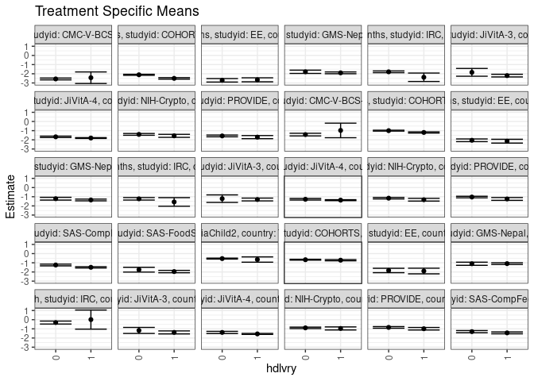

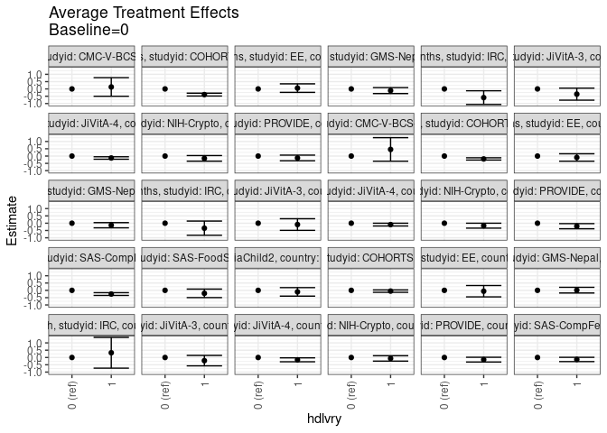

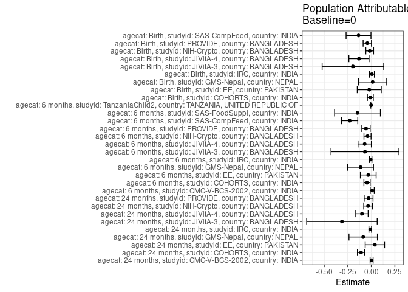

## Results Table

### Parameter: TSM

| agecat | studyid | country | intervention_level | baseline_level | estimate | ci_lower | ci_upper |
| --- | --- | --- | --- | --- | --- | --- | --- |
| Birth | COHORTS | INDIA | 0 | NA | -0.6657892 | -0.7127192 | -0.6188592 |
| Birth | COHORTS | INDIA | 1 | NA | -0.7175855 | -0.7845609 | -0.6506101 |
| Birth | EE | PAKISTAN | 0 | NA | -1.8394447 | -2.0786931 | -1.6001964 |
| Birth | EE | PAKISTAN | 1 | NA | -1.8982742 | -2.2066603 | -1.5898881 |
| Birth | GMS-Nepal | NEPAL | 0 | NA | -1.1051150 | -1.2761388 | -0.9340912 |
| Birth | GMS-Nepal | NEPAL | 1 | NA | -1.0922063 | -1.1861097 | -0.9983030 |
| Birth | IRC | INDIA | 0 | NA | -0.3138845 | -0.4765233 | -0.1512457 |
| Birth | IRC | INDIA | 1 | NA | 0.0100000 | -1.0310607 | 1.0510607 |
| Birth | JiVitA-3 | BANGLADESH | 0 | NA | -1.1731561 | -1.5014417 | -0.8448706 |
| Birth | JiVitA-3 | BANGLADESH | 1 | NA | -1.3888607 | -1.5513999 | -1.2263216 |
| Birth | JiVitA-4 | BANGLADESH | 0 | NA | -1.3903651 | -1.5105420 | -1.2701881 |
| Birth | JiVitA-4 | BANGLADESH | 1 | NA | -1.5497288 | -1.6044294 | -1.4950281 |
| Birth | NIH-Crypto | BANGLADESH | 0 | NA | -0.8921498 | -0.9725445 | -0.8117551 |
| Birth | NIH-Crypto | BANGLADESH | 1 | NA | -0.9553416 | -1.1209945 | -0.7896886 |
| Birth | PROVIDE | BANGLADESH | 0 | NA | -0.8422105 | -0.9323225 | -0.7520985 |
| Birth | PROVIDE | BANGLADESH | 1 | NA | -0.9881617 | -1.1253023 | -0.8510210 |
| Birth | SAS-CompFeed | INDIA | 0 | NA | -1.3043049 | -1.4241966 | -1.1844132 |
| Birth | SAS-CompFeed | INDIA | 1 | NA | -1.4383865 | -1.5399229 | -1.3368500 |
| 6 months | CMC-V-BCS-2002 | INDIA | 0 | NA | -1.4288687 | -1.5726614 | -1.2850760 |
| 6 months | CMC-V-BCS-2002 | INDIA | 1 | NA | -0.9754167 | -1.7693720 | -0.1814613 |
| 6 months | COHORTS | INDIA | 0 | NA | -1.0002850 | -1.0479537 | -0.9526163 |
| 6 months | COHORTS | INDIA | 1 | NA | -1.1958600 | -1.2603338 | -1.1313862 |
| 6 months | EE | PAKISTAN | 0 | NA | -2.0500608 | -2.1974625 | -1.9026591 |
| 6 months | EE | PAKISTAN | 1 | NA | -2.1483685 | -2.3557536 | -1.9409834 |
| 6 months | GMS-Nepal | NEPAL | 0 | NA | -1.2154976 | -1.3658857 | -1.0651094 |
| 6 months | GMS-Nepal | NEPAL | 1 | NA | -1.3547667 | -1.4497927 | -1.2597407 |
| 6 months | IRC | INDIA | 0 | NA | -1.2276901 | -1.3618868 | -1.0934933 |
| 6 months | IRC | INDIA | 1 | NA | -1.5693750 | -2.0379505 | -1.1007995 |
| 6 months | JiVitA-3 | BANGLADESH | 0 | NA | -1.2113215 | -1.6221181 | -0.8005250 |
| 6 months | JiVitA-3 | BANGLADESH | 1 | NA | -1.3032089 | -1.4570324 | -1.1493854 |
| 6 months | JiVitA-4 | BANGLADESH | 0 | NA | -1.2776107 | -1.3621588 | -1.1930625 |
| 6 months | JiVitA-4 | BANGLADESH | 1 | NA | -1.3731441 | -1.4229245 | -1.3233638 |
| 6 months | NIH-Crypto | BANGLADESH | 0 | NA | -1.1581738 | -1.2409558 | -1.0753917 |
| 6 months | NIH-Crypto | BANGLADESH | 1 | NA | -1.3276022 | -1.4751358 | -1.1800686 |
| 6 months | PROVIDE | BANGLADESH | 0 | NA | -1.0350866 | -1.1202827 | -0.9498905 |
| 6 months | PROVIDE | BANGLADESH | 1 | NA | -1.2405292 | -1.3950752 | -1.0859833 |
| 6 months | SAS-CompFeed | INDIA | 0 | NA | -1.2403474 | -1.3346382 | -1.1460565 |
| 6 months | SAS-CompFeed | INDIA | 1 | NA | -1.4941568 | -1.5656568 | -1.4226568 |
| 6 months | SAS-FoodSuppl | INDIA | 0 | NA | -1.7519222 | -2.0126809 | -1.4911635 |
| 6 months | SAS-FoodSuppl | INDIA | 1 | NA | -1.9579739 | -2.0889904 | -1.8269575 |
| 6 months | TanzaniaChild2 | TANZANIA, UNITED REPUBLIC OF | 0 | NA | -0.5416256 | -0.5929467 | -0.4903045 |
| 6 months | TanzaniaChild2 | TANZANIA, UNITED REPUBLIC OF | 1 | NA | -0.6457448 | -0.9327804 | -0.3587092 |
| 24 months | CMC-V-BCS-2002 | INDIA | 0 | NA | -2.5640139 | -2.6645275 | -2.4635003 |
| 24 months | CMC-V-BCS-2002 | INDIA | 1 | NA | -2.4300000 | -3.0592261 | -1.8007739 |
| 24 months | COHORTS | INDIA | 0 | NA | -2.1127545 | -2.1673751 | -2.0581338 |
| 24 months | COHORTS | INDIA | 1 | NA | -2.5013432 | -2.5824185 | -2.4202680 |
| 24 months | EE | PAKISTAN | 0 | NA | -2.7147626 | -2.9051573 | -2.5243679 |
| 24 months | EE | PAKISTAN | 1 | NA | -2.6590034 | -2.8779474 | -2.4400595 |
| 24 months | GMS-Nepal | NEPAL | 0 | NA | -1.7855927 | -1.9643389 | -1.6068465 |
| 24 months | GMS-Nepal | NEPAL | 1 | NA | -1.9005178 | -1.9994884 | -1.8015472 |
| 24 months | IRC | INDIA | 0 | NA | -1.7871446 | -1.8820825 | -1.6922068 |
| 24 months | IRC | INDIA | 1 | NA | -2.3818750 | -2.8405973 | -1.9231527 |
| 24 months | JiVitA-3 | BANGLADESH | 0 | NA | -1.8451807 | -2.2682119 | -1.4221496 |
| 24 months | JiVitA-3 | BANGLADESH | 1 | NA | -2.2025746 | -2.3464683 | -2.0586808 |
| 24 months | JiVitA-4 | BANGLADESH | 0 | NA | -1.6730213 | -1.7492437 | -1.5967988 |
| 24 months | JiVitA-4 | BANGLADESH | 1 | NA | -1.8040634 | -1.8476485 | -1.7604783 |
| 24 months | NIH-Crypto | BANGLADESH | 0 | NA | -1.4066439 | -1.5047134 | -1.3085743 |
| 24 months | NIH-Crypto | BANGLADESH | 1 | NA | -1.5645279 | -1.7296038 | -1.3994520 |
| 24 months | PROVIDE | BANGLADESH | 0 | NA | -1.5735409 | -1.6694328 | -1.4776491 |
| 24 months | PROVIDE | BANGLADESH | 1 | NA | -1.7032326 | -1.8723478 | -1.5341175 |

### Parameter: E(Y)

| agecat | studyid | country | intervention_level | baseline_level | estimate | ci_lower | ci_upper |
| --- | --- | --- | --- | --- | --- | --- | --- |
| Birth | COHORTS | INDIA | NA | NA | -0.6762420 | -0.7093108 | -0.6431732 |
| Birth | EE | PAKISTAN | NA | NA | -1.8614286 | -2.0501173 | -1.6727398 |
| Birth | GMS-Nepal | NEPAL | NA | NA | -1.0909443 | -1.1734385 | -1.0084500 |
| Birth | IRC | INDIA | NA | NA | -0.3080412 | -0.4687931 | -0.1472894 |
| Birth | JiVitA-3 | BANGLADESH | NA | NA | -1.3684731 | -1.5219775 | -1.2149687 |
| Birth | JiVitA-4 | BANGLADESH | NA | NA | -1.5216453 | -1.5715117 | -1.4717789 |
| Birth | NIH-Crypto | BANGLADESH | NA | NA | -0.9094945 | -0.9809370 | -0.8380521 |
| Birth | PROVIDE | BANGLADESH | NA | NA | -0.8851020 | -0.9601332 | -0.8100709 |
| Birth | SAS-CompFeed | INDIA | NA | NA | -1.4401843 | -1.5334809 | -1.3468878 |
| 6 months | CMC-V-BCS-2002 | INDIA | NA | NA | -1.4189572 | -1.5607165 | -1.2771979 |
| 6 months | COHORTS | INDIA | NA | NA | -1.0458076 | -1.0793244 | -1.0122908 |
| 6 months | EE | PAKISTAN | NA | NA | -2.0826460 | -2.2022514 | -1.9630406 |
| 6 months | GMS-Nepal | NEPAL | NA | NA | -1.3296275 | -1.4093037 | -1.2499514 |
| 6 months | IRC | INDIA | NA | NA | -1.2344062 | -1.3658524 | -1.1029600 |
| 6 months | JiVitA-3 | BANGLADESH | NA | NA | -1.2787349 | -1.4248268 | -1.1326431 |
| 6 months | JiVitA-4 | BANGLADESH | NA | NA | -1.3481303 | -1.3904710 | -1.3057895 |
| 6 months | NIH-Crypto | BANGLADESH | NA | NA | -1.1986783 | -1.2700937 | -1.1272630 |
| 6 months | PROVIDE | BANGLADESH | NA | NA | -1.0916915 | -1.1661176 | -1.0172654 |
| 6 months | SAS-CompFeed | INDIA | NA | NA | -1.4699588 | -1.5446559 | -1.3952616 |
| 6 months | SAS-FoodSuppl | INDIA | NA | NA | -1.8986842 | -2.0118892 | -1.7854792 |
| 6 months | TanzaniaChild2 | TANZANIA, UNITED REPUBLIC OF | NA | NA | -0.5440573 | -0.5945614 | -0.4935533 |
| 24 months | CMC-V-BCS-2002 | INDIA | NA | NA | -2.5611005 | -2.6603759 | -2.4618252 |
| 24 months | COHORTS | INDIA | NA | NA | -2.2218335 | -2.2619519 | -2.1817151 |
| 24 months | EE | PAKISTAN | NA | NA | -2.6770382 | -2.8210532 | -2.5330231 |
| 24 months | GMS-Nepal | NEPAL | NA | NA | -1.8717982 | -1.9591776 | -1.7844189 |
| 24 months | IRC | INDIA | NA | NA | -1.7987775 | -1.8923914 | -1.7051636 |
| 24 months | JiVitA-3 | BANGLADESH | NA | NA | -2.1571821 | -2.2993457 | -2.0150186 |
| 24 months | JiVitA-4 | BANGLADESH | NA | NA | -1.7725918 | -1.8111207 | -1.7340629 |
| 24 months | NIH-Crypto | BANGLADESH | NA | NA | -1.4412646 | -1.5249156 | -1.3576135 |
| 24 months | PROVIDE | BANGLADESH | NA | NA | -1.6024221 | -1.6857420 | -1.5191023 |

### Parameter: ATE

| agecat | studyid | country | intervention_level | baseline_level | estimate | ci_lower | ci_upper |
| --- | --- | --- | --- | --- | --- | --- | --- |
| Birth | COHORTS | INDIA | 0 | 0 | 0.0000000 | 0.0000000 | 0.0000000 |
| Birth | COHORTS | INDIA | 1 | 0 | -0.0517964 | -0.1332649 | 0.0296721 |
| Birth | EE | PAKISTAN | 0 | 0 | 0.0000000 | 0.0000000 | 0.0000000 |
| Birth | EE | PAKISTAN | 1 | 0 | -0.0588295 | -0.4488667 | 0.3312078 |
| Birth | GMS-Nepal | NEPAL | 0 | 0 | 0.0000000 | 0.0000000 | 0.0000000 |
| Birth | GMS-Nepal | NEPAL | 1 | 0 | 0.0129087 | -0.1814699 | 0.2072873 |
| Birth | IRC | INDIA | 0 | 0 | 0.0000000 | 0.0000000 | 0.0000000 |
| Birth | IRC | INDIA | 1 | 0 | 0.3238845 | -0.7298036 | 1.3775727 |
| Birth | JiVitA-3 | BANGLADESH | 0 | 0 | 0.0000000 | 0.0000000 | 0.0000000 |
| Birth | JiVitA-3 | BANGLADESH | 1 | 0 | -0.2157046 | -0.5726734 | 0.1412641 |
| Birth | JiVitA-4 | BANGLADESH | 0 | 0 | 0.0000000 | 0.0000000 | 0.0000000 |
| Birth | JiVitA-4 | BANGLADESH | 1 | 0 | -0.1593637 | -0.2924622 | -0.0262652 |
| Birth | NIH-Crypto | BANGLADESH | 0 | 0 | 0.0000000 | 0.0000000 | 0.0000000 |
| Birth | NIH-Crypto | BANGLADESH | 1 | 0 | -0.0631918 | -0.2476324 | 0.1212488 |
| Birth | PROVIDE | BANGLADESH | 0 | 0 | 0.0000000 | 0.0000000 | 0.0000000 |
| Birth | PROVIDE | BANGLADESH | 1 | 0 | -0.1459512 | -0.3091670 | 0.0172647 |
| Birth | SAS-CompFeed | INDIA | 0 | 0 | 0.0000000 | 0.0000000 | 0.0000000 |
| Birth | SAS-CompFeed | INDIA | 1 | 0 | -0.1340816 | -0.2808769 | 0.0127137 |
| 6 months | CMC-V-BCS-2002 | INDIA | 0 | 0 | 0.0000000 | 0.0000000 | 0.0000000 |
| 6 months | CMC-V-BCS-2002 | INDIA | 1 | 0 | 0.4534520 | -0.3534193 | 1.2603234 |
| 6 months | COHORTS | INDIA | 0 | 0 | 0.0000000 | 0.0000000 | 0.0000000 |
| 6 months | COHORTS | INDIA | 1 | 0 | -0.1955750 | -0.2749822 | -0.1161678 |
| 6 months | EE | PAKISTAN | 0 | 0 | 0.0000000 | 0.0000000 | 0.0000000 |
| 6 months | EE | PAKISTAN | 1 | 0 | -0.0983077 | -0.3532190 | 0.1566036 |
| 6 months | GMS-Nepal | NEPAL | 0 | 0 | 0.0000000 | 0.0000000 | 0.0000000 |
| 6 months | GMS-Nepal | NEPAL | 1 | 0 | -0.1392691 | -0.3172814 | 0.0387431 |
| 6 months | IRC | INDIA | 0 | 0 | 0.0000000 | 0.0000000 | 0.0000000 |
| 6 months | IRC | INDIA | 1 | 0 | -0.3416849 | -0.8290982 | 0.1457284 |
| 6 months | JiVitA-3 | BANGLADESH | 0 | 0 | 0.0000000 | 0.0000000 | 0.0000000 |
| 6 months | JiVitA-3 | BANGLADESH | 1 | 0 | -0.0918873 | -0.4903684 | 0.3065937 |
| 6 months | JiVitA-4 | BANGLADESH | 0 | 0 | 0.0000000 | 0.0000000 | 0.0000000 |
| 6 months | JiVitA-4 | BANGLADESH | 1 | 0 | -0.0955335 | -0.1901172 | -0.0009498 |
| 6 months | NIH-Crypto | BANGLADESH | 0 | 0 | 0.0000000 | 0.0000000 | 0.0000000 |
| 6 months | NIH-Crypto | BANGLADESH | 1 | 0 | -0.1694285 | -0.3391130 | 0.0002561 |
| 6 months | PROVIDE | BANGLADESH | 0 | 0 | 0.0000000 | 0.0000000 | 0.0000000 |
| 6 months | PROVIDE | BANGLADESH | 1 | 0 | -0.2054426 | -0.3813762 | -0.0295091 |
| 6 months | SAS-CompFeed | INDIA | 0 | 0 | 0.0000000 | 0.0000000 | 0.0000000 |
| 6 months | SAS-CompFeed | INDIA | 1 | 0 | -0.2538095 | -0.3481756 | -0.1594433 |
| 6 months | SAS-FoodSuppl | INDIA | 0 | 0 | 0.0000000 | 0.0000000 | 0.0000000 |
| 6 months | SAS-FoodSuppl | INDIA | 1 | 0 | -0.2060518 | -0.4982141 | 0.0861106 |
| 6 months | TanzaniaChild2 | TANZANIA, UNITED REPUBLIC OF | 0 | 0 | 0.0000000 | 0.0000000 | 0.0000000 |
| 6 months | TanzaniaChild2 | TANZANIA, UNITED REPUBLIC OF | 1 | 0 | -0.1041192 | -0.3956502 | 0.1874118 |
| 24 months | CMC-V-BCS-2002 | INDIA | 0 | 0 | 0.0000000 | 0.0000000 | 0.0000000 |
| 24 months | CMC-V-BCS-2002 | INDIA | 1 | 0 | 0.1340139 | -0.5031898 | 0.7712175 |
| 24 months | COHORTS | INDIA | 0 | 0 | 0.0000000 | 0.0000000 | 0.0000000 |
| 24 months | COHORTS | INDIA | 1 | 0 | -0.3885888 | -0.4871106 | -0.2900669 |
| 24 months | EE | PAKISTAN | 0 | 0 | 0.0000000 | 0.0000000 | 0.0000000 |
| 24 months | EE | PAKISTAN | 1 | 0 | 0.0557591 | -0.2362981 | 0.3478164 |
| 24 months | GMS-Nepal | NEPAL | 0 | 0 | 0.0000000 | 0.0000000 | 0.0000000 |
| 24 months | GMS-Nepal | NEPAL | 1 | 0 | -0.1149251 | -0.3194998 | 0.0896496 |
| 24 months | IRC | INDIA | 0 | 0 | 0.0000000 | 0.0000000 | 0.0000000 |
| 24 months | IRC | INDIA | 1 | 0 | -0.5947304 | -1.0631739 | -0.1262869 |
| 24 months | JiVitA-3 | BANGLADESH | 0 | 0 | 0.0000000 | 0.0000000 | 0.0000000 |
| 24 months | JiVitA-3 | BANGLADESH | 1 | 0 | -0.3573938 | -0.7698904 | 0.0551028 |
| 24 months | JiVitA-4 | BANGLADESH | 0 | 0 | 0.0000000 | 0.0000000 | 0.0000000 |
| 24 months | JiVitA-4 | BANGLADESH | 1 | 0 | -0.1310422 | -0.2161051 | -0.0459793 |
| 24 months | NIH-Crypto | BANGLADESH | 0 | 0 | 0.0000000 | 0.0000000 | 0.0000000 |
| 24 months | NIH-Crypto | BANGLADESH | 1 | 0 | -0.1578840 | -0.3495303 | 0.0337623 |
| 24 months | PROVIDE | BANGLADESH | 0 | 0 | 0.0000000 | 0.0000000 | 0.0000000 |
| 24 months | PROVIDE | BANGLADESH | 1 | 0 | -0.1296917 | -0.3232385 | 0.0638551 |

### Parameter: PAR

| agecat | studyid | country | intervention_level | baseline_level | estimate | ci_lower | ci_upper |
| --- | --- | --- | --- | --- | --- | --- | --- |
| Birth | COHORTS | INDIA | 0 | NA | -0.0104528 | -0.0419775 | 0.0210718 |
| Birth | EE | PAKISTAN | 0 | NA | -0.0219838 | -0.1493353 | 0.1053677 |
| Birth | GMS-Nepal | NEPAL | 0 | NA | 0.0141707 | -0.1347495 | 0.1630909 |
| Birth | IRC | INDIA | 0 | NA | 0.0058433 | -0.0208468 | 0.0325333 |
| Birth | JiVitA-3 | BANGLADESH | 0 | NA | -0.1953169 | -0.5221413 | 0.1315075 |
| Birth | JiVitA-4 | BANGLADESH | 0 | NA | -0.1312802 | -0.2382806 | -0.0242799 |
| Birth | NIH-Crypto | BANGLADESH | 0 | NA | -0.0173448 | -0.0586536 | 0.0239641 |
| Birth | PROVIDE | BANGLADESH | 0 | NA | -0.0428915 | -0.0871543 | 0.0013712 |
| Birth | SAS-CompFeed | INDIA | 0 | NA | -0.1358795 | -0.2679407 | -0.0038183 |
| 6 months | CMC-V-BCS-2002 | INDIA | 0 | NA | 0.0099115 | -0.0113762 | 0.0311993 |
| 6 months | COHORTS | INDIA | 0 | NA | -0.0455226 | -0.0788212 | -0.0122241 |
| 6 months | EE | PAKISTAN | 0 | NA | -0.0325852 | -0.1161837 | 0.0510133 |
| 6 months | GMS-Nepal | NEPAL | 0 | NA | -0.1141300 | -0.2512205 | 0.0229605 |
| 6 months | IRC | INDIA | 0 | NA | -0.0067162 | -0.0197457 | 0.0063134 |
| 6 months | JiVitA-3 | BANGLADESH | 0 | NA | -0.0674134 | -0.4278392 | 0.2930123 |
| 6 months | JiVitA-4 | BANGLADESH | 0 | NA | -0.0705196 | -0.1412672 | 0.0002280 |
| 6 months | NIH-Crypto | BANGLADESH | 0 | NA | -0.0405046 | -0.0781589 | -0.0028502 |
| 6 months | PROVIDE | BANGLADESH | 0 | NA | -0.0566049 | -0.1009816 | -0.0122283 |
| 6 months | SAS-CompFeed | INDIA | 0 | NA | -0.2296114 | -0.3155487 | -0.1436741 |
| 6 months | SAS-FoodSuppl | INDIA | 0 | NA | -0.1467620 | -0.3898319 | 0.0963078 |
| 6 months | TanzaniaChild2 | TANZANIA, UNITED REPUBLIC OF | 0 | NA | -0.0024318 | -0.0092690 | 0.0044055 |
| 24 months | CMC-V-BCS-2002 | INDIA | 0 | NA | 0.0029133 | -0.0131417 | 0.0189684 |
| 24 months | COHORTS | INDIA | 0 | NA | -0.1090791 | -0.1475618 | -0.0705963 |
| 24 months | EE | PAKISTAN | 0 | NA | 0.0377244 | -0.0650907 | 0.1405395 |
| 24 months | GMS-Nepal | NEPAL | 0 | NA | -0.0862056 | -0.2370635 | 0.0646524 |
| 24 months | IRC | INDIA | 0 | NA | -0.0116329 | -0.0258108 | 0.0025451 |
| 24 months | JiVitA-3 | BANGLADESH | 0 | NA | -0.3120014 | -0.6863164 | 0.0623136 |
| 24 months | JiVitA-4 | BANGLADESH | 0 | NA | -0.0995705 | -0.1654954 | -0.0336456 |
| 24 months | NIH-Crypto | BANGLADESH | 0 | NA | -0.0346207 | -0.0807307 | 0.0114893 |
| 24 months | PROVIDE | BANGLADESH | 0 | NA | -0.0288812 | -0.0757780 | 0.0180156 |